# Day 15

Taylor R. Brown

1/3/2020

# Roadmap

9.1

- back to non-time series situation
- **importance sampling** -> self-normalized importance sampling
- mostly proof-free (classical asymptotics)

9.2

- sampling importance resampling

9.3

- sequential importance sampling with resampling (single-step analysis)

9.4

- sequential importance sampling with resampling (multi-step analysis)

# Theorem 9.1.2 (first part)

Let $f$ be a real, measurable function such that $\mu(|f|) < \infty$ and $|f| \mu \ll \nu$ (note the typo in the book), and let $\xi^1, \xi^2, \ldots$ be a sequence of iid random variables from $\nu$. Then the unnormalized importance sampling estimator
$$\tilde{\mu}^{\text{IS}}_{\nu, N}(f) = \frac{1}{N} \sum_{i=1}^N f(\xi^i) \frac{d\mu}{d\nu}(\xi^i)$$
is strongly consistent.

This is just the ordinary strong law of large numbers.

# Theorem 9.1.2 (second part)

If in addition
$$E_{\nu}\left[f^2(\xi^i) \frac{d\mu}{d\nu}(\xi^i)^2 \right] < \infty,$$

then $\tilde{\mu}^{\text{IS}}_{\nu, N}$ is asymptotically normal, i.e.
$$\sqrt{N}\left(\tilde{\mu}^{\text{IS}}_{\nu, N}(f) - \mu(f) \right) \overset{\text{D}}{\to} \text{Normal} \left(0, \text{Var}_{\nu}\left[ f(\xi^i) \frac{d\mu}{d\nu}(\xi^i)\right] \right)$$

This is just the regular central limit theorem.

# Theorem 9.1.2 in practice

- $|f| \mu \ll \nu$ is weaker than $\mu \ll \nu$
- infinite variance estimators are quite bad in practice
- pick $\nu$ carefully! (e.g. $P_{\mu}(\xi > 1e4) = E_{\mu}[\mathbb{1}(\xi > 1e4)]$)
- a rearrangement,
  $$\begin{align*}
  \text{Var}_{\nu}\left[ f(\xi^i) \frac{d\mu}{d\nu}(\xi^i)\right]
  &= E_{\nu}\left[ \left( f(\xi^i) \frac{d\mu}{d\nu}(\xi^i) - \nu\left[ f(\xi^i) \frac{d\mu}{d\nu}(\xi^i)\right]\right)^2 \right] \\
  &= E_{\nu}\left[ \left( f(\xi^i) \frac{d\mu}{d\nu}(\xi^i) - \mu(f)\right)^2 \right] \\
  &= \mu^2(f) \nu\left[ \left( \frac{f d\mu/d\nu}{\mu(f)} - 1\right)^2 \right] \\
  &\ge \mu^2(f) \nu\left[ \left( \frac{|f| d\mu/d\nu}{\mu(|f|)} - 1\right)^2 \right] \tag{typo in book}
  \end{align*}$$

# Theorem 9.1.2 in practice

$$\text{Var}_{\nu}\left[ f(\xi^i) \frac{d\mu}{d\nu}(\xi^i)\right]
= \mu^2(f) \nu\left[ \left( \frac{f d\mu/d\nu}{\mu(f)} - 1\right)^2 \right]$$

- $\frac{f d\mu/d\nu}{\mu(f)}$ has mean $1$ no matter what $\nu$ is, so we want to minimize the second moment or variance.
- $\frac{f d\mu/d\nu}{\mu(f)}$ close to $1$ with low variance means $f d\mu/d\nu$ is close-to-constant or flat.
- if $f$ is negligible, this means $\mu$ and $\nu$ are roughly the same.
- so, this is really only more useful than regular Monte-Carlo if $f$ is not negligible (which is pretty much always true).

# Example 9.1.3

- target: $\mu$ is $\text{Cauchy}(0,1)$ (fat tails)
- proposal: $\nu$ is $\text{Normal}(0,1)$ (thin tails)

$$\frac{d\mu}{d\nu}(x) = \frac{\frac{1}{\pi}\left(1 + x^2\right)^{-1} }{\frac{1}{\sqrt{2\pi}}\exp[-.5x^2] } \propto \exp[.5x^2]/(1+x^2)$$

# Example 9.1.3

plotting the RN derivative…

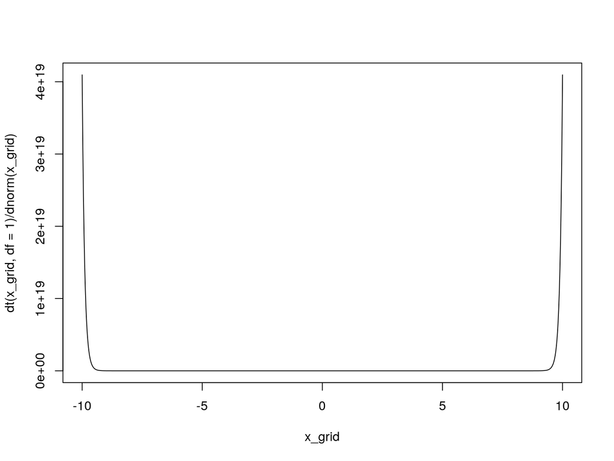

```r
x_grid <- seq(-10,10,.01)
plot(x_grid, dt(x_grid, df=1)/dnorm(x_grid), type="l") # not flat!
```

# Example 9.1.3

plotting $x \frac{d\mu}{d\nu}(x)$

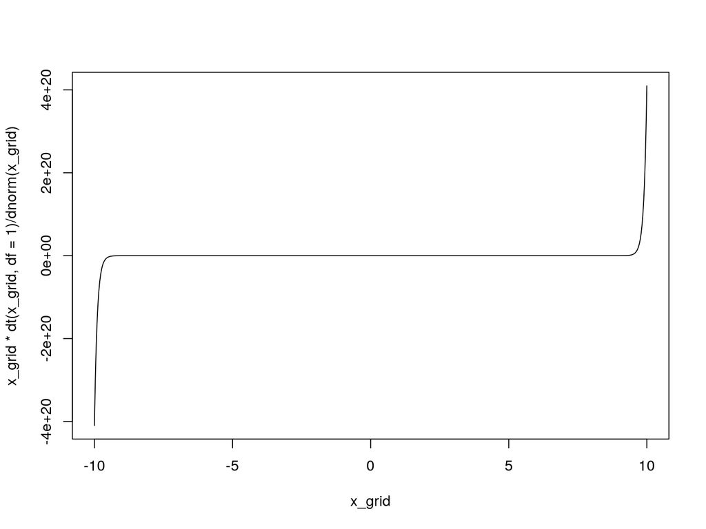

```r
x_grid <- seq(-10,10,.01)
plot(x_grid, x_grid * dt(x_grid, df=1)/dnorm(x_grid), type="l") # not flat!
```

# Example 9.1.3

plotting $\mathbf{1}(|x| < 3) \frac{d\mu}{d\nu}(x)$

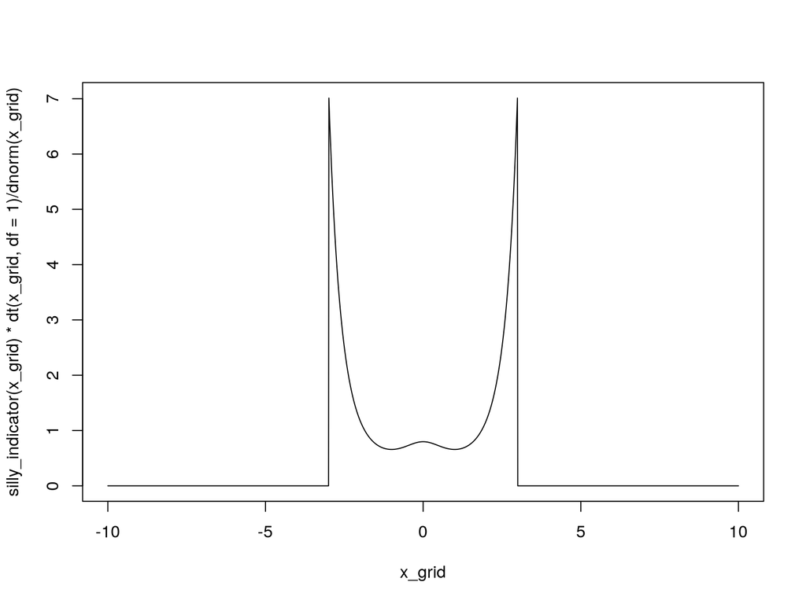

```r
x_grid <- seq(-10,10,.01)
silly_indicator <- function(x) ifelse(abs(x) < 3, 1, 0)
plot(x_grid, silly_indicator(x_grid) * dt(x_grid, df=1)/dnorm(x_grid), type="l") # not too un-flat
```

# Example 9.1.4

now switch the target and the proposal!

$$\frac{d\mu}{d\nu}(x) \propto (1+x^2)/\exp[.5x^2]$$

# Example 9.1.4

plotting the RN derivative…

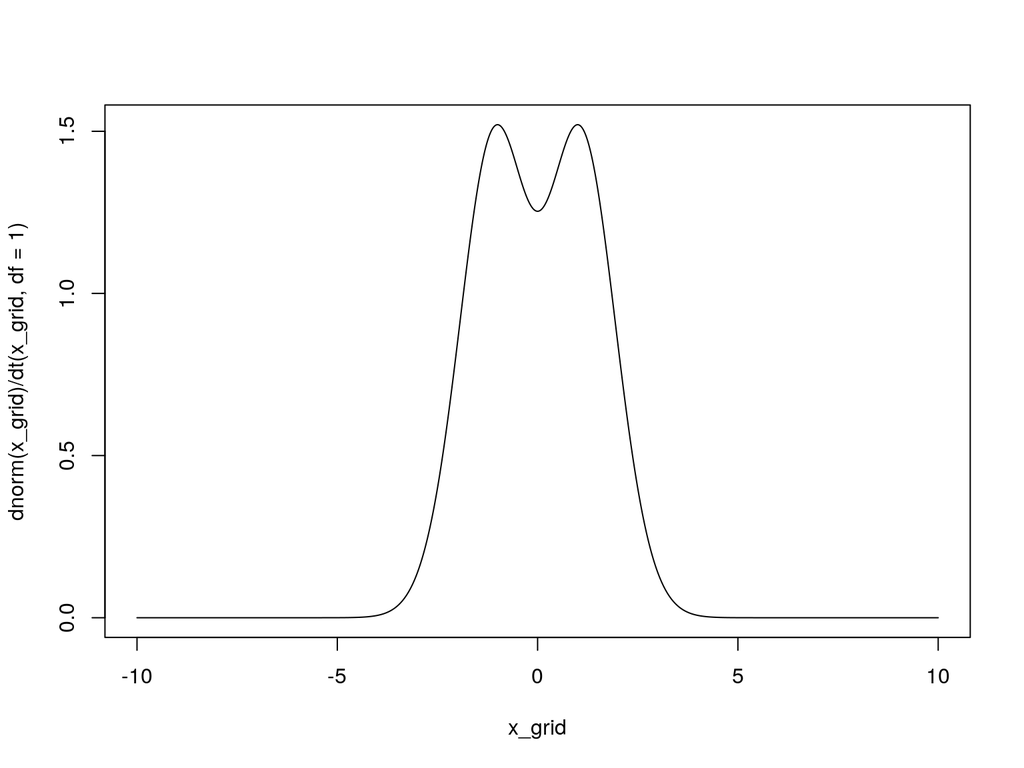

```r
x_grid <- seq(-10,10,.01)
plot(x_grid, dnorm(x_grid)/dt(x_grid, df=1), type="l") # better!
```

# Example 9.1.4

plotting $x \frac{d\mu}{d\nu}(x)$

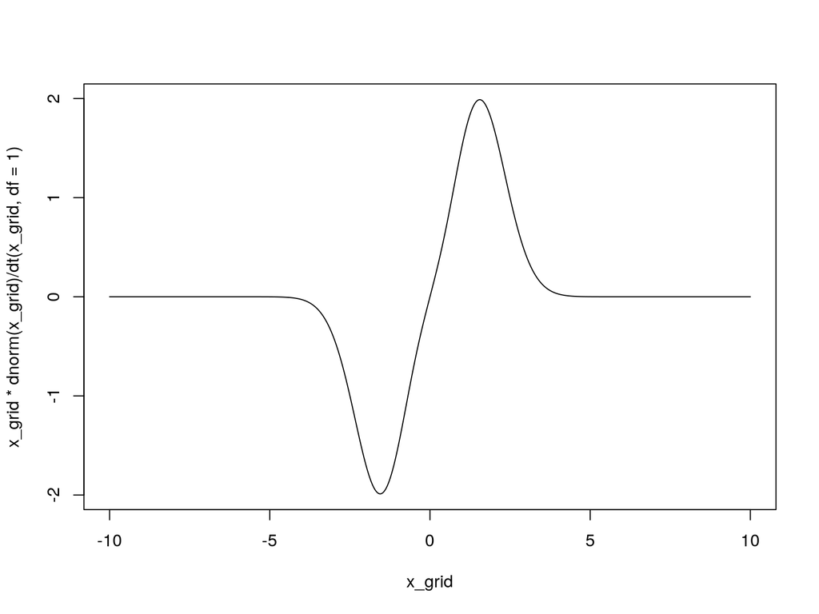

```r
x_grid <- seq(-10,10,.01)
plot(x_grid, x_grid * dnorm(x_grid)/dt(x_grid, df=1), type="l") # better!
```

# Example 9.1.4

plotting $\mathbf{1}(|x| < 3) \frac{d\mu}{d\nu}(x)$

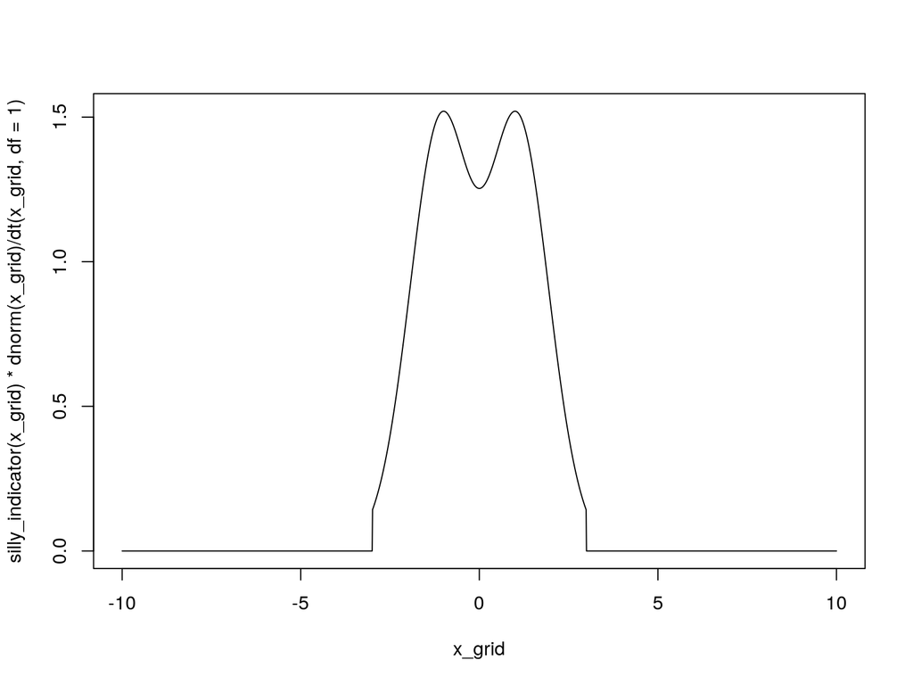

```r
x_grid <- seq(-10,10,.01)
plot(x_grid, silly_indicator(x_grid) * dnorm(x_grid)/dt(x_grid, df=1), type="l") # better!
```